```python
from IPython.display import HTML

HTML('''<script>
code_show=true;
function code_toggle() {
 if (code_show){
 $('div.input').hide();
 } else {
 $('div.input').show();
 }
 code_show = !code_show
}
$( document ).ready(code_toggle);
</script> <a href="javascript:code_toggle()"></a>''')
```

# Public Relation Analysis for UNITED Airlines

Twitter, Facebook and other social media platforms are a necessity in every organization to build a successful relationship with customers. Companies use these platforms to engage with their customers and promote their product and services. However, as a result of this unprecedented direct access, Public Relations (PR) management has significantly changed. In the event of a PR issue or disaster, customers now expect a swift, open and honest response from the respective organization through social media.

In recent years, some companies were able to avert a PR crisis by quickly and openly addressing the problem. For example, when Southwest flight 345 had a landing incident at LaGuardia airport, people received the news within minutes on Twitter and were able to follow the situation through frequent updates provided by Southwest. On the other side of the spectrum, the recent United Airlines (UA) incident in which a customer was forcefully dragged out of an airplane and the airline reaction was an example of extremely poor PR management. Within a day the issue escalated to a full blown PR crisis.

In this project, I will analyze some recent PR issues, such as the the United Airlines and American Airline (AA) incidents. My plan is to find insight by looking at tweets crawled from twitter website. I will explore the United Airlines incident and compare it to the similar American Airlines incident that happened a couple of weeks later but did not create a PR crisis.

For future work, I will analyze other events like SouthWest airline PR, and see if we can find patterns of their PR being responsive, and the twitter reaction.

## Analysis of Tweets Frequency and Events:

I use frequency of tweets that have mentions of United Airlines or American Airlines as one metric for good or poor PR management. A good management plan should be capable of preventing an incident from going viral (i.e., large number of tweets or “high frequency”). A poor PR plan will not bring the frequency down, and might even make the situation worse. To get a better insight of a company PR plan, I show the timeline of the company’s reactions on the tweet frequency plot, to be able to correlate reactions with outcome. At this stage, I assume that the overall sentiment of tweets in these type of situation are negative. I plan to show this fact using sentiment analysis later in my capstone project.

The first set of plots (Plots #1,#2,#3) show tweets frequency for AA and UA incidents. From the time the first UA video is uploaded, till the time twitter starts showing reactions (April 10th, noon-ish), UA does not take any meaningful action to calm down the situation (Plot #2). Even worst, at 12:27pm, the CEO, Munoz issued a statement, hoping he would smooth things over with a superficial apology about the “re-accommodation” incident. His words fueled the internet fire and things got out of control. Later on, at 7:30pm, United issued an internal memo to employees and blamed the victim for what happened. After some delay, the memo found its way to the twitter, and again the reactions are visible. Finally, on April 11th at 3:10 pm, CEO Munoz apologized and promised to “make it right.” It is very interesting to see that twitter activity drops significantly within few hours of the apology.

Now on the American Airlines recent incident, from the time the first video emerged to the time that AA issued a sincere apology and took responsibility was about 8 hours (Plot #3). Twitter activity shows drastic difference between this incident and the UA incident. At the end, AA PR management contained the issue and it never became a national news or a crisis.

### Plot #1: Events Plot for American Airlines and United Airlines

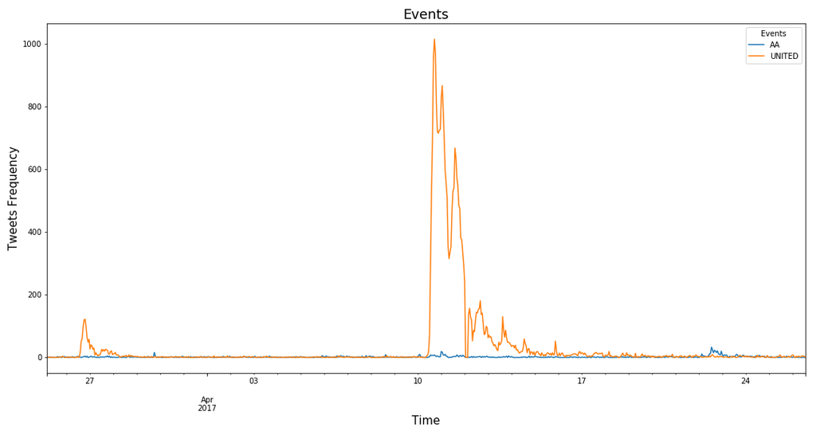

```python
from IPython.display import Image
Image(filename='TDI/timeseries_events_3.png')
```

### Plot #2: Zoomed Events Graph for United Airlines

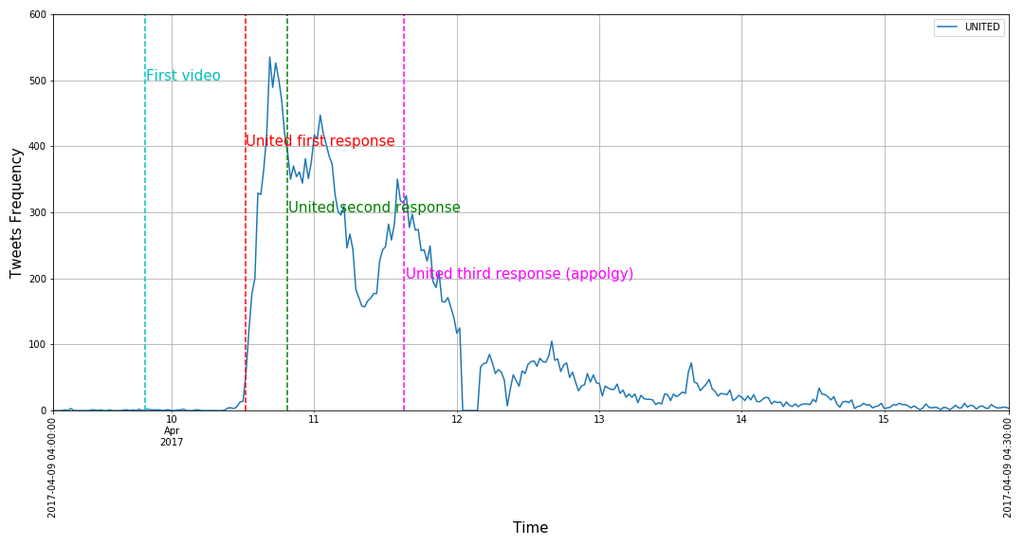

```python
Image(filename='TDI/timeseries_ua_zoom_3.png')
```

### Plot #3: Zoomed Events for American Airlines

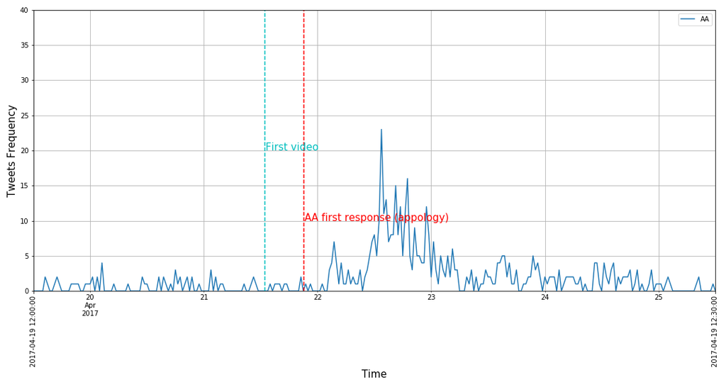

```python
Image(filename='TDI/timeseries_aa_zoom_3.png')
```

For the next stage of this analysis, I would like to investigate how number of favorites and followers of United account has changed during this time.

## Discovering Stories by Topic Modeling

For this part of the analysis, I give an overview of stories covered in the twitter collection using topic modeling and clustering tweets together as stories. I would like to see if we can get an overview of important events being discussed in this collection without actually spending time to go through tweets. I have taken several steps to create clusters of tweets that are less noisy and more informative, including:

- divided my twitter collection into time slices of one week.
- extracted tweets that have mentions of United or American Airlines such as #newunitedairlinesmottos #unitedairlines #united @united #boycottunited @americanair #americanairline #americanair
- removed stop words, common twitter words, punctuations.
- used NLTK tweet tokenizer to tokenize tweets
- normalized data, TFIDF
- topic modeling, Latent Semantic Analysis
- added a probability threshold to further remove the noise tweets in each cluster.

By using this topic modeling approach, I wanted to see at a glance what stories and events have happened for that brand (UA and AA in our case study) without spending time to go through the hassle of reading all tweets of this period. The stories are being generated automatically so, the topic words and story words are not refined and are not in a form of sentences. They are just representative of the tweet words in each cluster. Please see below the representative words for stories being covered in this collection:

### Table #1: United Airline Stories March 26th - April 26th

```python
import pandas as pd
import csv

pd_csv = pd.read_csv('/Users/alinamazi/Documents/DI/Stories.csv')
pd_csv_indexed = pd_csv.set_index(['Date', 'Name'])

def highlight_Stories(s):
    arr1 = s.index.get_level_values(1)=='Topic #1'
    arr2 = s.index.get_level_values(0)=='1st week: March 26 - April 01'
    arr3 = s.index.get_level_values(0)=='4th week: April 16 - April 22'
    is_highlight = arr1 & (arr2 | arr3)
    return ['background-color: yellow' if v else 'color: darkblue' for v in is_highlight]

s = pd_csv_indexed.style.apply(highlight_Stories)
s
```

| Date | Name | Tweet Count | Stories |
| --- | --- | --- | --- |
| 1st week: March 26 - April 01 | Topic #1 | 79 | leggings dress wear girls united wearing flight women fly |
|  | Topic #2 | 65 | dress code pass free employee policy employees flying |
|  | Topic #3 | 25 | united fly airlines flying flight policy |
| 2nd week: April 02 - April 08 | Topic #1 | 17 | united flight airlines airline know worst fly hours take only |
|  | Topic #2 | 14 | states finance kingdom take need united close bulls |
|  | Topic #3 | 13 | flight hours lmao only hold delayed minutes connecting |
| 3rd week: April 09 - April 15 | Topic #1 | 805 | united airlines flight passenger dragged overbooked plane doctor |
|  | Topic #2 | 139 | fly airline skies friendly plane beat |
|  | Topic #3 | 16 | ceo oscar munoz customers plane |
| 4th week: April 16 - April 22 | Topic #1 | 73 | flight united airlines wedding seat flying couple booted airline bride |
|  | Topic #2 | 51 | united airlines plane beating fly man fired |
|  | Topic #3 | 16 | plane being dragged wedding passenger bride groom couple |
| 5th week: April 23 - April 26 | Topic #1 | 24 | flight rabbit crew airlines giant dies animals united report dragged |

An interesting fact in stories of 1st week (Topic #2) is about “dress code employee policy” which seems to have tweets about the event that two girls were prohibited to board because they were wearing leggings. When you investigate more, you will notice that the girls had “United employee” tickets and for that ticket you need to have a formal dress code.

Also, I can see that the UA incident (dragging a man out of UA airplane) has been dominant for at least two weeks. On the other hand, we don’t see this pattern for AA incident. I predict that until UA and the passenger reach a settlement, the discussions on twitter will be continued. I can further investigate this in the next stage of my capstone project.

Among 3rd week stories there is another interesting finding. A motto that has been used by United Airlines for years which is “Fly the Friendly Skies” has been sarcastically used several times during this week.

It is interesting to see two other events besides the dragging a man out of UA airplane story for UA, in the 4th week and 5th week. One of them is related to a couple en-route to their wedding destination were kicked off their United flight. The second is death of Simon the giant rabbit, which was flying with UA.

### Table #2: American Airline Stories Discovered From March 26th - April 26th

For American Airlines stories, mostly you will see normal topics, like flight cancelation and delays. Although the mentioned incident is being discovered in the stories, we don't see a very large number of tweet counts assigned to that story.

```python
pd_csv_aa = pd.read_csv('/Users/alinamazi/Documents/DI/Stories_aa.csv')
pd_csv_indexed_aa = pd_csv_aa.set_index(['Date', 'Name'])

def highlight_Stories(s):
    arr1 = s.index.get_level_values(1)=='Topic #1'
    arr2 = s.index.get_level_values(0)=='4th week: April 16 - April 22'
    is_highlight = arr1 & arr2

    return ['background-color: yellow' if v else 'color: darkblue' for v in is_highlight]

s = pd_csv_indexed_aa.style.apply(highlight_Stories)
s
```

| Date | Name | Tweet Count | Stories |
| --- | --- | --- | --- |
| 2nd week: April 02 - April 08 | Topic #1 | 18 | light hours cancelled delay still airport plane crew |
|  | Topic #2 | 11 | airport help departure bags miss explain trying |
| 4th week: April 16 - April 22 | Topic #1 | 30 | american flight attendant hit passenger employee airlines stroller mother woman |
|  | Topic #2 | 12 | american airlines need respect |